# STAT 6502 Annotated Class Notes

We start with an example where $H_0$ is true: $\mu_X = \mu_Y$.

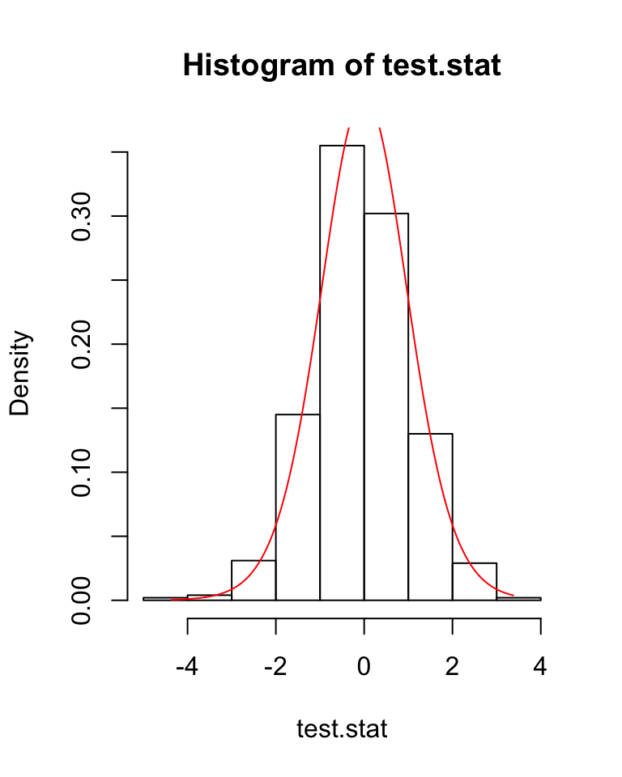

```r
# Welch's result
# unequal variances, both unknon

var.x <- 15     # true population variance of the Xs
var.y <- 9          # true population variance of the Ys

mu.x <- 5           # true population mean of the Xs
mu.y <- 5           # true population mean of the Ys

n <- 10         # sample size of Xs
m <- 10         # sample size of Ys

B <- 1000       # number of simulated samples

test.stat <- numeric(B) # test statistic values

# simulation according to parameter
for (i in 1:B) {
    x <- rnorm(n, mu.x, sqrt(var.x))
    y <- rnorm(m, mu.y, sqrt(var.y))
    test.stat[i] <- t.test(x,y,var.equal=FALSE)$statistic
}

df <- (var.x/n+var.y/m)^2/( (var.x/n)^2/(n-1) + (var.y/m)^2/(m-1))
hist(test.stat, freq=FALSE)
t <- seq(min(test.stat), max(test.stat), length=1000)
lines(t, dt(t,df), col='red') # overlay with the null distribution
```

```r
# When null is true, we expect the null distribution follows t-distribution
```

Now we’ll let $\mu_Y=7$ so that the $H_0$ is false.

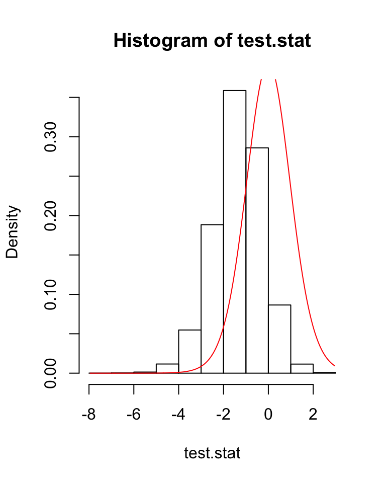

```r
# Welch's result
# unequal variances, both unknon

var.x <- 15     # true population variance of the Xs
var.y <- 9          # true population variance of the Ys

mu.x <- 5           # true population mean of the Xs
mu.y <- 7           # true population mean of the Ys

n <- 10         # sample size of Xs
m <- 10         # sample size of Ys

B <- 10000      # number of simulated samples

test.stat <- numeric(B) # test statistic values

# simulation according to parameter
for (i in 1:B) {
    x <- rnorm(n, mu.x, sqrt(var.x))
    y <- rnorm(m, mu.y, sqrt(var.y))
    test.stat[i] <- t.test(x,y,var.equal=FALSE)$statistic
}

df <- (var.x/n+var.y/m)^2/( (var.x/n)^2/(n-1) + (var.y/m)^2/(m-1))
hist(test.stat, freq=FALSE)
t <- seq(min(test.stat), max(test.stat), length=1000)
lines(t, dt(t,df), col='red') # overlay with the null distribution
```

Notice that there is a lot of overlap, which tells us that our power is low. This is due in large part similar means and small sample sizes.

Last, increase $\mu_Y$ to $12$.

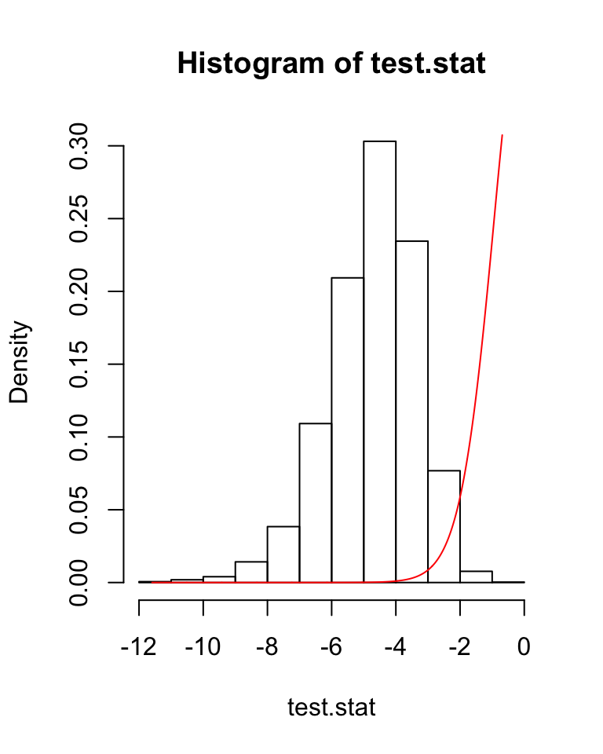

```r
# Welch's result
# unequal variances, both unknon

var.x <- 15     # true population variance of the Xs
var.y <- 9          # true population variance of the Ys

mu.x <- 5           # true population mean of the Xs
mu.y <- 12          # true population mean of the Ys

n <- 10         # sample size of Xs
m <- 10         # sample size of Ys

B <- 10000      # number of simulated samples

test.stat <- numeric(B) # test statistic values

# simulation according to parameter
for (i in 1:B) {
    x <- rnorm(n, mu.x, sqrt(var.x))
    y <- rnorm(m, mu.y, sqrt(var.y))
    test.stat[i] <- t.test(x,y,var.equal=FALSE)$statistic
}

df <- (var.x/n+var.y/m)^2/( (var.x/n)^2/(n-1) + (var.y/m)^2/(m-1))
hist(test.stat, freq=FALSE)
t <- seq(min(test.stat), max(test.stat), length=1000)
lines(t, dt(t,df), col='red') # overlay with the null distribution
```

Power is much greater.

### Paired Samples

Clearly, we are now in the situation where the samples are no longer independent. This means that we will have a nonzero covariance in the standard error of $\overline{Y} - \overline{X}$.

We will now assume that the differences of the pairs $D_1, \dots, D_n$, are normally distributed. If we assume observations within a sample are independent, but the $i^{th}$ observation in one sample is related to the $i^{th}$ observation in the other sample, then $D_1, \dots, D_n$ are independent with
$$\begin{aligned}
\text{Var}(\overline{D}) &= \text{Var}(\overline{X} - \overline{Y}) \\
&= \text{Var}\bigg(\frac{1}{n} \sum_{i=1}^n (X_i - Y_i)\bigg) \\
&= \frac{1}{n^2} \sum_{i=1}^n \text{Var}(X_i - Y_i) \\
&= \frac{1}{n^2} \sum_{i=1}^n [\text{Var}(X_i) + \text{Var}(Y_i) - 2\text{Cov}(X_i, Y_i)] \\
&= \frac{1}{n^2} (n\sigma^2_X + n\sigma^2_Y - 2n \sigma_{XY}) \\
&= \text{Var}(\overline{X}) + \text{Var}(\overline{Y}) - \frac{2}{n}\sigma_{XY}
\end{aligned}$$

- $(X_i - Y_i)$’s are independent, so variance of the sums are equal to the sum of the variances. But $X_i$’s are not independent from $Y_i$’s, so $\text{Var}(X_i - Y_i) \neq \sigma^2_X + \sigma^2_Y$.
- The value of $\text{Cov}(X_i, Y_i)$ does not depend on $i$, $\text{Cov}(X_i, Y_i) = \sigma_{XY}$.

If we ignore the pairing (assume that $X_i$ and $Y_i$ are independent), and there is a positive relationship between $X$ and $Y$, then $_{XY} > 0 $, and we would be overestimating variance, $\text{Var}(\overline{D})$. A negative relationship would cause us to underestimate the variance. The consequence is that the confidence interval for a *t*-test would be too wide (overestimating the variance) or too narrow.

In practice, we do not estimate the covariance directly. Rather, we estimate $\text{Var}(\overline{D}) = \frac{\text{Var}(D)}{n}$ with the sample variance of the differences.
$$\begin{aligned}
\widehat{\text{Var}}(\overline{D}) &= \widehat{\text{Var}}(\overline{X} - \overline{Y}) \\
&= \frac{s_X^2}{n} + \frac{s_Y^2}{n} - \frac{2}{n}s_{XY} \\
&= \frac{1}{n-1} \sum_{i=1}^n [(X_i - Y_i) - (\overline{X} - \overline{Y})]^2/n \\
&= \underbrace{\frac{1}{n-1} \sum_{i=1}^n [D_i - \overline{D}]^2}_{\text{sample variance of the differences}}/n \\
&= \frac{s_D^2}{n}
\end{aligned}$$

This can now be viewed as a one-sample problem on the differences rather than a two-sample problem on the $X$’s and $Y$’s ($D_i$’s are i.i.d.).

This leads to the test statistic
$$T = \frac{\overline{D} - \mu_{D_0}}{s_D/\sqrt{n}}$$
which, under $H_0$, follows a *t*-distribution with $df=n-1$.

Note: $\mu_{D_0}$ is usually zero.

### Testing for Independence (Test for $\rho$)

Recall that for bivariate normal random variables $X$ and $Y$, the correlation coefficient, $\rho$, is zero iff they are independent. Thus a test for independence is equivalent to a test for a $\rho=0$,
$$H_0: \rho = 0 \ \ \ \text{vs.} \ \ \ H_1: \rho \neq 0$$
For bivariate normal random variables $X$ and $Y$, their joint pdf is
$$f_{XY}(x,y) = \frac{1}{2 \pi \sigma_X \sigma_Y \sqrt{1 - \rho^2}} \exp \Bigg\{- \frac{1}{2(1 - \rho)^2} \bigg[\bigg(\frac{x - \mu_X}{\sigma_X}\bigg)^2 + \bigg(\frac{y - \mu_Y}{\sigma_Y}\bigg)^2 - 2 \rho \frac{(x - \mu_X)(y - \mu_Y)}{\sigma_X \sigma_Y}\bigg] \Bigg\}$$

- This is 3-dimensional: it includes $x, y,$ and the density.
- Note that this pdf describes a single pair of observations. We are interested in multiple pairs, so we need to derive a likelihood.

Therefore, if we are talking about $n$ independent bivariate points $(x_1,y_1), \dots, (x_n, y_n)$, and letting $\boldsymbol{\theta} = (\mu_X, \mu_Y, \sigma_X^2, \sigma_Y^2, \rho)$, then the log-likelihood function is
$$\ell(\boldsymbol{\theta}) = -n \ln\bigg(2 \pi \sigma_X \sigma_Y \sqrt{1 - \rho^2}\bigg) - \frac{1}{2(1 - \rho^2)} \Bigg[\frac{\sum_{i=1}^n (x_i - \mu_X)^2}{\sigma_X^2} + \frac{\sum_{i=1}^n (y_i - \mu_Y)^2}{\sigma_Y^2} - \frac{2 \rho \sum_{i=1}^n (x_i - \mu_X)(y_i - \mu_Y)}{\sigma_X \sigma_Y} \Bigg]$$
Determining the mle’s of the five parameters requires taking five partial derivatives wrt each parameter, setting the derivative to zero, and solving for the parameter to find the maximum. Those steps will be omitted.

So the unrestricted maximum likelihood estimator of $\boldsymbol{\theta}$ is
$$\begin{aligned}
\boldsymbol{\theta} &= (\overline{X}, \overline{Y}, \hat{\sigma}_X^2, \hat{\sigma}^2_Y, \hat{\rho}) \ \ \text{where} \\
& \\
\hat{\sigma}_X^2 &= \frac{1}{n} \sum_{i=1}^n (X_i - \overline{X})^2 \\
\hat{\sigma}_Y^2 &= \frac{1}{n} \sum_{i=1}^n (Y_i - \overline{Y})^2 \\
\hat{\rho} &= \frac{\sum_{i=1}^n (X_i - \overline{X})(Y_i - \overline{Y})}{n \hat{\sigma}_X \hat{\sigma}_Y}
\end{aligned}$$
If $H_0$ is true (meaning that $\rho = 0$), then we have two independent samples, and $\hat{\boldsymbol{\theta}}_0$ can be obtained by separately maximizing the likelihood of $X_1, \dots, X_n$ and $Y_1, \dots, Y_n$. We have $\hat{\boldsymbol{\theta}}_0 = (\overline{X}, \overline{Y}, \hat{\sigma}_X^2, \hat{\sigma}^2_Y, \rho=0)$, and therefore
$$\begin{aligned}
- 2\ln \Lambda &= 2[\ell(\hat{\boldsymbol{\theta}}) - \ell(\hat{\boldsymbol{\theta}}_0)] \\
&= 2 \bigg[-n \ln(2\pi \hat{\sigma}_X \hat{\sigma}_Y) - \frac{n}{2} \ln (1 - \hat{\rho}^2) - n\bigg] - 2 \bigg[-n \ln(2 \pi \hat{\sigma}_X \hat{\sigma}_Y) - n \bigg] \\
&= - n \ln(1 - \hat{\rho}^2)
\end{aligned}$$
The LR statistic is an increasing function of $\hat{\rho}^2$ since $\rho^2$ can only take values between $0$ and $1$. So we reject $H_0$ for large values $\hat{\rho}^2$ or $\big| \hat{\rho} \big|$.

In order to obtain a rejection region we need the distribution of $\hat{\rho}$, or an equivalent statistic, under $H_0$.

Now
$$\hat{\rho} = \frac{\sum_{i=1}^n (U_i - \overline{U})(V_i - \overline{V})}{\big[\sum_{i=1}^n (U_i - \overline{U})^2\big]^{1/2} \big[\sum_{i=1}^n (V_i - \overline{V})^2\big]^{1/2}}$$
where $U_i = \frac{X_i - \mu_X}{\sigma_X}$ and $V_i = \frac{Y_i - \mu_Y}{\sigma_Y}$.

- If $X_i$ and $Y_i$ follow a normal distribution, then $U_i$ and $V_i$ also follow a normal distribution.

Because $(U_1, V_1), \dots, (U_n, V_n)$ is a smaple from $N(0,0,1,1,\rho)$, the distribution of $\hat{\rho}$ depends only on $\rho$. If $\rho = 0$, then
$$T= \frac{\sqrt{n-2}\hat{\rho}}{\sqrt{1 - \hat{\rho}^2}}$$
has a *t*-distribution with $df=n-2$.

When $\rho \neq 0$, there is no simple form for the distribution of $\hat{\rho}$ (or $T$). However, a normal approximation is available.

For any $\alpha$, the power function of the LR test is symmetric about $\rho=0$ and increases continuously from $\alpha$ to one, as $|\rho|$ goes from $0$ to $1$.

### Distribution of $\hat{\rho} (=r)$

Under $H_0: \rho = 0$, the sample correlation coefficient calculated from bivariate normal data has pdf
$$f_R(r) = \frac{1}{\Gamma\big(\frac{1}{2}\big)} \frac{\Gamma\big(\frac{n-1}{2}\big)}{\Gamma\big(\frac{n-2}{2}\big)} (1 - r^2)^{(n-4)/2} \ \ \ -1 < r < 1$$
If we let $u=\frac{R\sqrt{n-2}}{\sqrt{1 - R^2}}$, then
$$R = \frac{u}{\sqrt{n-2+u^2}} = g(u)$$
Taking the derivative, we get
$$\begin{aligned}
\frac{dg(u)}{du} &= \frac{(n-2 + u^2)^{1/2}(1) - u \frac{1}{2}(n-2+u^2)^{-1/2}(2u)}{(\sqrt{n-2+u^2})^2} \\
&= \frac{1}{\sqrt{n-2+u^2}} - \frac{u^2}{(n-2+u^2)^{3/2}} \\
&= \frac{1}{\sqrt{n-2+u^2}} - \bigg(1 - \frac{u^2}{n-2+u^2}\bigg)
\end{aligned}$$
Using the change-of-variable technique and letting $v=n-2$, we have
$$\begin{aligned}
f_u(u) &= \frac{1}{\Gamma\big(\frac{1}{2}\big)} \frac{\Gamma\big(\frac{v+1}{2}\big)}{\Gamma\big(\frac{v}{2}\big)} \bigg(1 - \frac{u^2}{v+u^2}\bigg)^{(v-2)/2} \frac{1}{\sqrt{v + u^2}}\bigg(1 - \frac{u^2}{v + u^2} \bigg) \\
&= \frac{\Gamma\big(\frac{v+1}{2}\big)}{\sqrt{\pi} \Gamma\big(\frac{v}{2}\big)} \bigg(1 - \frac{u^2}{v+u^2}\bigg)^{v/2} \bigg( \frac{1}{v + u^2}\bigg)^{1/2} \bigg(\frac{v}{v}^{1/2}\bigg) \\
&= \frac{\Gamma\big(\frac{v+1}{2}\big)}{\sqrt{v \pi} \Gamma\big(\frac{v}{2}\big)} \bigg(1 + \frac{u^2}{v}\bigg)^{-v/2} \bigg(1 + \frac{u^2}{v}\bigg)^{-1/2} \\
&= \frac{\Gamma\big(\frac{v+1}{2}\big)}{\sqrt{v \pi} \Gamma\big(\frac{v}{2}\big)} \bigg(1 + \frac{u^2}{v} \bigg)^{-(v+1)/2} \ \ \ -\infty < u < \infty
\end{aligned}$$
which is the pdf of a random variable following a *t*-distribution with $df=v=n-2$.

**March 02, 2016**

### Nonparametric Methods

**Permutation Test (Randomization Test)**  
Suppose we have two samples (one from each population) of size $n_1$ and $n_2$ with $n_1 + n_2 = n$.

The idea of the permutation test is to compare two populations as follows:

1. if there really is no difference between the populations, then from the *n* total observations, it should not matter which $n_1$ of them are assigned to sample $1$, and the rest, $n_2$, sample $2$.
2. if we do the above for all possible permutations, we can calculate $D$, the difference in means (or medians, variances, quartiles, or whatever) of the two samples.
3. we calculate the *p*-value by calculating the proportion of these $D$’s that are as, or more, extreme as the $D$ from the original data.

**Example** Suppose we want to compare the average time spent studying by students in a graduate course vs. students in an undergraduate course.

Let our data be $g=\{4, 5, 5, 8, 9\}$ and $u=\{3, 4, 2, 5\}$.

Just by looking at the data, we can see that it is unlikely to be normally distributed. This is because there is a lower bound (i.e. $0$) but no upper bound. Some students may spend 0 hours studying, but some may spend 20 hours studying. A larger sample would likely reveal that the distribution is right-skewed. So a nonparametric method is appropriate.

There are $\binom{9}{5}=126$ ways to assign 5 of 9 people into group $g$, where order is unimportant.

Using the professor’s `R` script, `permutation_sim.R`

```r
# perm.test
# a is the first sample
# b is the second sample
# c is the number of permuations to simulate

perm.test = function(a,b,c=10000, alt=c("two.sided")){
  obs.dif = mean(b) - mean(a)
    dat = c(a,b)
    na = length(a)
    nb = length(b)
    n = length(a)+length(b)
    dif.perm = numeric(c)

    for (i in 1:c){
        ind = sample(1:n, na, replace = FALSE)
        a.random = dat[ind]
        b.random = dat[!1:n %in% ind]
        dif.perm[i] = mean(b.random) - mean(a.random)
    }
    if (alt=="greater") p.value = sum( dif.perm >= obs.dif)/c
    if (alt=="less") p.value = sum( dif.perm <= obs.dif)/c
    if (alt=="two.sided") p.value = sum( abs(dif.perm) >= abs(obs.dif))/c
    return(p.value)
}
```

Now enter in data

```r
u <- c(3, 4, 2, 5)
g <- c(4, 5, 5, 8, 9)
perm.test(u, g) # two-sided test
```

```
## [1] 0.1202
```

```r
perm.test(u, g, alt="greater") # test to show grad students study more
```

```
## [1] 0.0596
```

If we were to apply the t-test:

```r
t.test(u, g, equal.var=FALSE, alt="less")
```

```
##
##  Welch Two Sample t-test
##
## data:  u and g
## t = -2.3181, df = 6.602, p-value = 0.02786
## alternative hypothesis: true difference in means is less than 0
## 95 percent confidence interval:
##        -Inf -0.4731101
## sample estimates:
## mean of x mean of y
##       3.5       6.2
```

The permutation is more appropriate here, but it has less power than a t-test.

What we are actually testing in the previous example is
$$H_0: F_g(x) = F_u(x) \ \ \ \text{vs.} \ \ \ H_1: F_g(x) \leq F_u(x),$$
where strict inequality occurs for at least one $x$.

The null hypothesis says the two distributions are identical whereas the alternative says the observations from the $g$ group tend to be larger than that of the $u$ group.

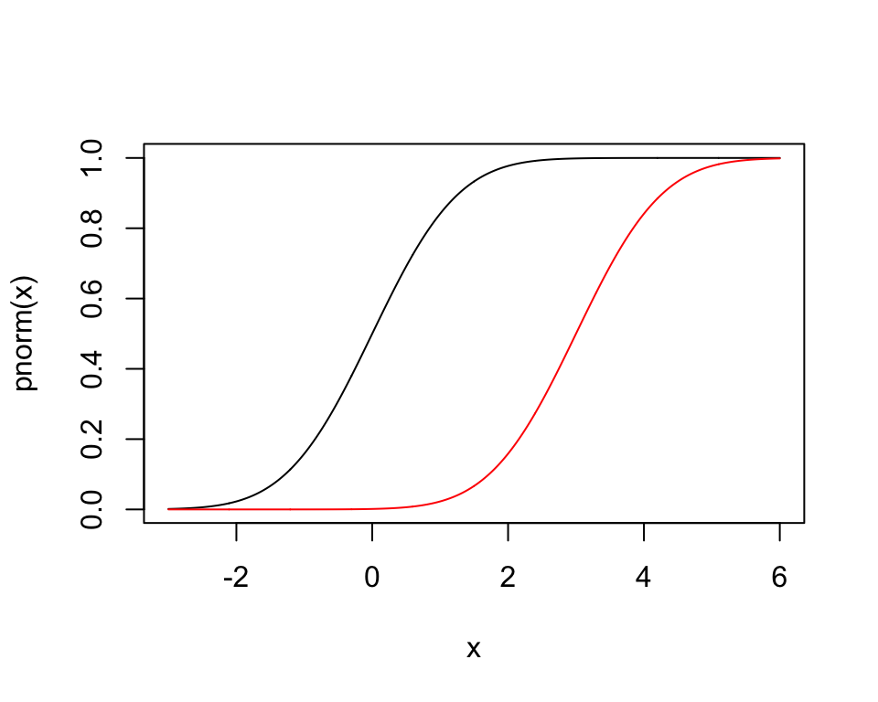

```r
x <- seq(-3, 6, length=1000)
plot(x, pnorm(x), type='l')
lines(x, pnorm(x, 3), col='red')
```

The statement above is the same as $H_1: \mu_g > \mu_u$ in the parametric case.

We can also have the one-sided alternative
$$H_1: F_g(x) \geq F_u(x)$$
or the two-sided alternative
$$H_1: F_g(x) \geq F_u(x) \ \ \text{or} F_g(x) \leq F_u(x)$$
This can be useful since the researcher is free to choose any statistic (e.g. median) that he/she feels best describes the difference between two groups.

Using the approximation (simulated) to the exact permutation, then some theory says that we have about a $95\%$ chance of being within
$$\pm \sqrt{\frac{1(1-p)}{R}}$$
of $p$, the true *p*-value, where $R$ is the number of simulated permutations.

### Wilcoxon Rank Sum Test

This is a two-sample permutation test on the ranks between the two groups.

For this, we assume that there are no ties (we will deal with this later).

Let $X_1, \dots, X_n$ denote the set of $n$ observations. The rank $X_i$ among the *n* observations, denoted $R(X_i)$ is given by
$$R(X_i) = \text{number of X's $\leq$ X_i}$$
The test statistic is $W$, the sum of the ranks from one of the groups.

In `R`, we use the function `wilcox.test()`.

```r
wilcox.test(u, g, alt='less') #only approximate because of ties.
```

```
##
##  Wilcoxon rank sum test with continuity correction
##
## data:  u and g
## W = 2.5, p-value = 0.03993
## alternative hypothesis: true location shift is less than 0
```

**Example** Let group 1 be $\{15, 16, 18, 20\}$ and group 2 be $\{10, 11, 24, 13, 17\}$. Therefore, the ranks for group 1 are $\{4, 5, 7, 8\}$ and for group 2 are $\{1, 2, 9, 3, 6\}$

```r
a <- c(15, 16, 18, 20)
b <- c(10, 11, 24, 13, 17)
wilcox.test(a, b, alt='greater')
```

```
##
##  Wilcoxon rank sum test
##
## data:  a and b
## W = 14, p-value = 0.2063
## alternative hypothesis: true location shift is greater than 0
```

```r
wilcox.test(a, b, conf.int=TRUE) # obtain confidence interval
```

```
##
##  Wilcoxon rank sum test
##
## data:  a and b
## W = 14, p-value = 0.4127
## alternative hypothesis: true location shift is not equal to 0
## 95 percent confidence interval:
##  -8  9
## sample estimates:
## difference in location
##                    3.5
```

**March 07, 2016**

### Regression

**Estimation**
In large models, it is often easier to represent the model in matrix form:
$$\mathbf{Y} = X + \boldsymbol{\beta} + \boldsymbol{\epsilon}$$
where $\mathbf{Y}$ and $\boldsymbol{\epsilon}$ are $n \times 1$ vectors, $\boldsymbol{\beta}$ is a $p \times 1$ vector, and $X$ is an $n \times p$ (design) matrix.
$$\begin{bmatrix} Y_1 \\ Y_2 \\ \vdots \\ Y_n \end{bmatrix}
=
\begin{bmatrix} 1 & X_{11} & X_{12} & \dots & X_{1, p-1} \\
1 & X_{21} & X_{22} & \dots & X_{2, p-1} \\
\vdots & \vdots & \vdots & \ddots & \vdots \\
1 & X_{n1} & X_{n2} & \dots & X_{n, p-1} \\
\end{bmatrix}
\begin{bmatrix} \beta_0 \\ \beta_1 \\ \vdots \\ \beta_{p-1} \end{bmatrix}
+
\begin{bmatrix} \epsilon_0 \\ \epsilon_1 \\ \vdots \\ \epsilon_{p-1} \end{bmatrix}$$
The maximum likelihood procedure is as follows:
$$\begin{aligned}
L(\boldsymbol{\beta}, \sigma^2) &= (2 \pi \sigma^2)^{-n/2} \exp\bigg\{- \frac{1}{2\sigma^2} \sum_{i=1}^n \Big(Y_i - \beta_0 - \sum_{j=1}^{p-1} \beta_j - X_{ij} \Big)^2 \bigg\} \\
&= (2 \pi \sigma^2)^{-n/2} \exp\bigg\{- \frac{1}{2\sigma^2} \sum_{i=1}^n (\mathbf{Y} - X \boldsymbol{\beta})^T (\mathbf{Y} -X \boldsymbol{\beta}) \bigg\}
\end{aligned}$$
where the latter equation is a matrix representation to the former.

The log-likelihood is
$$\begin{aligned}
\ell(\boldsymbol{\beta}, \sigma^2) &= - \frac{n}{2} \ln(2 \pi \sigma^2) - \frac{1}{2 \sigma^2} (\mathbf{Y} - X \boldsymbol{\beta})^T (\mathbf{Y} - X \boldsymbol{\beta}) \\
&= - \frac{n}{2} \ln(2 \pi \sigma^2) - \frac{1}{2 \sigma^2} \Big[ \mathbf{Y}^T \mathbf{Y} - \mathbf{Y}^T X \boldsymbol{\beta} - \boldsymbol{\beta}^T X^T \mathbf{Y} + \boldsymbol{\beta}^T X^T X \boldsymbol{\beta} \Big]
\end{aligned}$$
Note that $\mathbf{Y}_{1 \times n}^T X_{n \times p} \boldsymbol{\beta}_{p \times 1}$ yields a $1 \times 1$ matrix, or a scalar. So $- \mathbf{Y}^T X \boldsymbol{\beta} - \boldsymbol{\beta}^T X^T \mathbf{Y} = - 2 \boldsymbol{\beta}^T X^T \mathbf{Y}$. So we have
$$\ell(\boldsymbol{\beta}, \sigma^2) = - \frac{n}{2} \ln(2 \pi \sigma^2) - \frac{1}{2 \sigma^2} \Big[ \mathbf{Y}^T \mathbf{Y} - 2 \boldsymbol{\beta}^T X^T \mathbf{Y} + \boldsymbol{\beta}^T X^T X \boldsymbol{\beta} \Big]$$

Next we take the derivative with respect to $\boldsymbol{\beta}$. Note that taking the derivative of $\boldsymbol{\beta}^T X^T X \boldsymbol{\beta}$ employs the chain rule.
$$\frac{d \ell (\boldsymbol{\beta}, \sigma^2)}{d \boldsymbol{\beta}} = - 0 - \frac{1}{2 \sigma^2} \Big[0 -2 X^T \mathbf{Y} + X^T \ X \boldsymbol{\beta} + (X^T X)^T \boldsymbol{\beta} \Big]$$
$X_{p \times n}^T X_{n \times p}$ is a symmetric matrix, so $X^T \ X \boldsymbol{\beta}= (X^T X)^T\boldsymbol{\beta}$. This allows us to combine those terms
$$\begin{aligned}
\frac{d \ell (\boldsymbol{\beta}, \sigma^2)}{d \boldsymbol{\beta}} &= -\frac{1}{2\sigma^2} (-2X^T \mathbf{Y} + 2X^T X \boldsymbol{\beta}) \\
&= -\frac{1}{\sigma^2} (-X^T \mathbf{Y} + X^T X \boldsymbol{\beta})
\end{aligned}$$
Setting this to zero yields the normal equations
$$X^T X \boldsymbol{\beta} = X^T \mathbf{Y}$$
Solving for $\boldsymbol{\beta}$ gives
$$\hat{\boldsymbol{\beta}} = (X^T X)^{-1} X^T \mathbf{Y}$$
provided that $(X^T X )^{-1}$ exists.

In STAT 6509, we may have encountered $\hat{\boldsymbol{\beta}}$ as
$$\hat{\boldsymbol{\beta}} = [b_0, b_1, \dots, b_{p-1}]$$
Checking the second derivative yields $-\frac{1}{\sigma^2}X^TX$ where $X^T X$ is nonnegative definite.

The existence of $(X^T X)^{-1}$ is determined by looking at $X$. Specifically, $X$ needs to be full rank, the columns are linearly independent.

Substituting in $\hat{\boldsymbol{\beta}} = (X^T X)^{-1} X^T \mathbf{Y}$, the fitted values can be rewritten as
$$\begin{aligned}
\hat{\mathbf{Y}} &= X \hat{\boldsymbol{\beta}} \\
&= \underbrace{X(X^T X)^{-1} X^T}_{\equiv H} \mathbf{Y}
\end{aligned}$$
Here $H$ is called the hat matrix and is a projection on the column space of $X$ having the properties

- symmetric: $H^T=H$
- idempotent: $HH=H$
- $HX=X$

The residuals are defined as the difference between the observed values and fitted values: $\mathbf{e} = \mathbf{Y}-\hat{\mathbf{Y}}$. Since $\hat{\mathbf{Y}} = H\mathbf{Y}$, we may rewrite the residuals as
$$\begin{aligned}
\mathbf{e} &= \mathbf{Y}-\hat{\mathbf{Y}} \\
&= \mathbf{Y} - H \mathbf{Y} \\
&= (I - H)\mathbf{Y}
\end{aligned}$$
where $I$ is the identity matrix.

Finding the expected value of $\hat{\boldsymbol{\beta}}$ is trivial since
$$\begin{aligned}
E(\hat{\boldsymbol{\beta}}) &= E[(X^T X)^{-1} X^T \mathbf{Y}] \\
&= (X^T X)^{-1} X^T E(\mathbf{Y}) \\
&= (X^T X)^{-1} X^T (X \boldsymbol{\beta}) \\
&= \boldsymbol{\beta}
\end{aligned}$$

Note that Var$(\mathbf{Y})=I_{n\times n} \sigma^2$ and the $X$’s are fixed, so the variance-covariance matrix, denoted $\Sigma_{\hat{\boldsymbol{\beta}}}$, is
$$\begin{aligned}
\Sigma_{\hat{\boldsymbol{\beta}}} &= \text{Var}(\hat{\boldsymbol{\beta}}) \\
&= \text{Var}((X^T X)^{-1} X^T \mathbf{Y}) \\
&= (X^T X)^{-1} X^T \text{Var}(\mathbf{Y}) [(X^T X)^{-1} X^T]^T \ \ \ (*)\\
&= \sigma^2 (X^T X)^{-1}
\end{aligned}$$
(*) What happens when pulling a matrix of constants out of the variance.

$\Sigma_{\hat{\boldsymbol{\beta}}} = \sigma^2 (X^T X)^{-1}$ is nice and elegant but generally not that useful since $\sigma^2$ is usually unknown.So if $\sigma^2$ is unknown, we must rely on an estimate. The MLE of $\sigma^2$ is
$$\hat{\sigma}^2 = \frac{(\mathbf{Y} - X \boldsymbol{\beta})^T (\mathbf{Y} - X \boldsymbol{\beta})}{n}$$
which is a biased estimate.

Note that
$$\begin{aligned}
E(\hat{\sigma}^2) &= \frac{1}{n} E(\mathbf{e}^T \mathbf{e}) \\
&= \frac{1}{n} E \Big( \big[ (I - H)\mathbf{Y} \big]^T \big[ (I - H)\mathbf{Y} \big] \Big) \\
&= \frac{1}{n} E [\mathbf{Y}^T (I - H)^T (I - H) \mathbf{Y} ] \\
&= \frac{1}{n} E[\mathbf{Y}^T (I - H) \mathbf{Y} ] \\
&= \frac{1}{n} \big[E(\mathbf{Y}^T) \underbrace{(I - H)E(\mathbf{Y})}_{=0} + \sigma^2 \underbrace{\text{trace}(I - H)}_{=n-p} \big]
\end{aligned}$$
where the trace of a matrix is the sum of the diagonal elements.

To see how we got the results of two components of the last equation, we have
$$\begin{aligned}
(I - H)E(\mathbf{Y}) &= \big(I - X(X^T X)^{-1} X^T \big) X \boldsymbol{\beta} \\
&= I \cdot X \boldsymbol{\beta} - X(X^T X)^{-1} X^T \cdot X \boldsymbol{\beta} \\
&= X \boldsymbol{\beta} - X I \boldsymbol{\beta} \\
&= 0
\end{aligned}$$
For the other term, we can utilize two properties of the trace. It is a linear operator $\Big($ meaning, $\text{trace}(I - H) = \text{trace}(I) - \text{trace}(H) \Big)$, and matrices can be reordered without any effect on the final evaluation of a trace $\Big($ meaning, $\text{trace}\big(X(X^T X)^{-1} X^T\big) = \text{trace}\big(X^T X(X^T X)^{-1}\big)\Big)$. So
$$\begin{aligned}
\text{trace}(I - H) &= \text{trace}(I_{n \times n}) - \text{trace}(H) \\
&= n - \text{trace}(X(X^T X)^{-1} X^T) \\
&= n - \text{trace}(X^T X(X^T X)^{-1}) \\
&= n - p
\end{aligned}$$
Returning back to the expected value of the estimated variance,
$$E(\hat{\sigma}^2) = \frac{1}{n} \sigma^2 (n - p)$$
which yields the bias $- \frac{p}{n}\sigma^2$.

Typically (which was seen in STAT 6509), we use MSE (SSE/df) as our estimator of $\sigma^2$ since
$$\begin{aligned}
E[MSE] &= E \bigg[\frac{\mathbf{e}^T \mathbf{e}}{n - p}\bigg] \\
&= \frac{1}{n-p} \sigma^2 (n-p) \\
&= \sigma^2
\end{aligned}$$
which is unbiased.

Finally,
$$\begin{aligned}
\hat{\Sigma}_{\hat{\boldsymbol{\beta}}} &= \widehat{\text{Var}}(\hat{\boldsymbol{\beta}}) \\
&= MSE(X^T X)^{-1}
\end{aligned}$$

**Proposition** If we assume $(X^T X )^{-1}$ exists, then

1. $\hat{\boldsymbol{\beta}} \sim N(\boldsymbol{\beta}, \sigma^2(X^T X)^{-1})$
2. $\frac{n \hat{\sigma}^2}{\sigma^2} \sim \chi^2_{(n-p)}$
3. $\hat{\boldsymbol{\beta}}$ and $\hat{\sigma}^2$ are independent.

**Proof**

1. $\hat{\boldsymbol{\beta}} \sim N(\boldsymbol{\beta}, \sigma^2(X^T X)^{-1})$:  
   Recall that $\mathbf{Y} \sim N(X \boldsymbol{\beta}, \sigma^2 I_{n \times n})$ and $\hat{\boldsymbol{\beta}} = (X^T X)^{-1} X^T \mathbf{Y}$. If $\hat{\boldsymbol{\beta}}$ is a linear function of $\mathbf{Y}$, and $\mathbf{Y}$ is normally distributed, then the linear function of a normal distribution is also normally distributed.
2. $\frac{n \hat{\sigma}^2}{\sigma^2} \sim \chi^2_{(n-p)}$:
   Note that
   $$\begin{aligned}
   H \hat{\boldsymbol{\beta}} &= H \mathbf{Y} \\
   &= H(X \boldsymbol{\beta} + \boldsymbol{\epsilon}) \\
   &= X \boldsymbol{\beta} + H \boldsymbol{\epsilon}
   \end{aligned}$$
   Thus
   $$\begin{aligned}
   (n-p) \frac{\text{MSE}}{\sigma^2} &= (n-p) \frac{\hat{\sigma}^2/(n-p)}{\sigma^2} \\
   &= \frac{\hat{\sigma}^2}{\sigma^2} \\
   &= \frac{1}{\sigma^2} \mathbf{Y}^T (I - H)^T (I - H) \mathbf{Y} \\
   &= \frac{1}{\sigma^2} \big[ (I - H) \mathbf{Y} \big]^T (I - H) \mathbf{Y} \\
   &= \frac{1}{\sigma^2}[(I - H)(X \boldsymbol{\beta} + \boldsymbol{\epsilon}) ]^T [(I - H)(X \boldsymbol{\beta} + \boldsymbol{\epsilon}) ] \\
   &= \frac{1}{\sigma^2} [I(X \boldsymbol{\beta} + \boldsymbol{\epsilon}) - H(X \boldsymbol{\beta} + \boldsymbol{\epsilon})]^T [I(X \boldsymbol{\beta} + \boldsymbol{\epsilon}) - H(X \boldsymbol{\beta} + \boldsymbol{\epsilon})] \\
   &= \frac{1}{\sigma^2} [(X \boldsymbol{\beta} + \boldsymbol{\epsilon}) - (\underbrace{HX}_{HX=X} \boldsymbol{\beta} + H\boldsymbol{\epsilon})]^T [(X \boldsymbol{\beta} + \boldsymbol{\epsilon}) - (\underbrace{HX}_{HX=X} \boldsymbol{\beta} + H\boldsymbol{\epsilon})] \\
   &= \frac{1}{\sigma^2} [(X \boldsymbol{\beta} + \boldsymbol{\epsilon}) - (X \boldsymbol{\beta} + H \boldsymbol{\epsilon})]^T [(X \boldsymbol{\beta} + \boldsymbol{\epsilon}) - (X \boldsymbol{\beta} + H \boldsymbol{\epsilon})] \\
   &= \frac{1}{\sigma^2} \boldsymbol{\epsilon}^T (I - H)^T (I - H) \boldsymbol{\epsilon} \\
   &= \frac{1}{\sigma^2} \boldsymbol{\epsilon}^T (I - H) \boldsymbol{\epsilon}
   \end{aligned}$$
   Since the rank of $(I - H)$ is $n - p$, using some properties about the functions of multivariate normal random variable
   $$\frac{1}{\sigma^2}\boldsymbol{\epsilon}^T (I - H) \boldsymbol{\epsilon} \sim \chi^2_{(n-p)}$$
3. $\hat{\boldsymbol{\beta}}$ and $\hat{\sigma}^2$ are independent:
   To show that $\hat{\boldsymbol{\beta}}$ and $\hat{\sigma}^2$ are independent, it suffices to show that $\hat{\boldsymbol{\beta}}$ and $\mathbf{Y} - X \hat{\boldsymbol{\beta}}$ are independent
   $$\hat{\boldsymbol{\beta}} = (X^T X)^{-1} X^T \mathbf{Y} = A \mathbf{Y}$$
   and
   $$\mathbf{Y} - X\hat{\boldsymbol{\beta}} = (I - H) \mathbf{Y} = B \mathbf{Y}$$
   It suffices to show that $AB$ is a matrix of zeroes
   $$\begin{aligned}
   AB &= (X^T X)^{-1} X^T (I - H) \\
   &= (X^T X)^{-1} X^T - (X^T X)^{-1} X^T H \\
   &= (X^T X)^{-1} X^T - (X^T X)^{-1} X^T \\
   &= 0
   \end{aligned}$$

**March 9, 2016**

## F-Tests

You have already seen that the overall F-test is a special case of the partial F-test.

Suppose we want to test the null hypothesis:  
$H_0: \beta_r = \beta_{r+1} = \cdots = \beta_{p-1} = 0$  
$H_1:$ at least one parameter is non-zero.

To implement the likelihood ratio test, we need to find the MLEs under $H_0$ as well as the unrestricted MLEs. We first define the “reduced” design matrix
$$X_r = \begin{bmatrix}
1 & X_{11} & X_{12} & \dots & X_{1, r-1} \\
1 & X_{21} & X_{22} & \dots & X_{2, r-1} \\
\vdots & \vdots & \ddots & \vdots \\
1 & X_{n1} & X_{n2} & \dots & X_{n, r-1} \\
\end{bmatrix}$$
where “r” refers to “reduced.” The reduced design matrix is similar to the regular design matrix but with fewer columns. It has fewer parameters/coefficients.

Determining the MLEs for a reduced model is the same as for a regular model - just add subscript “r.”

The MLEs of $\boldsymbol{\beta}$ are
$$\begin{aligned}
\hat{\boldsymbol{\beta}}_r &= (X_r^T X_r)^{-1} X_r^T \mathbf{Y} \ \ \ \text{(under $H_0$)} \\
\hat{\boldsymbol{\beta}} &= (X^T X)^{-1} X^T \mathbf{Y} \ \ \ \text{(unrestricted)}
\end{aligned}$$
while the MLEs of $\sigma^2$ are
$$\begin{aligned}
\hat{\sigma}^2_r &= \frac{1}{n}(\mathbf{Y} - X_r \hat{\boldsymbol{\beta}}_r)^T (\mathbf{Y} - X_r \hat{\boldsymbol{\beta}}_r) \\
&= \frac{1}{n} \mathbf{Y}^T (I - H_r) \mathbf{Y} \ \ \ \text{(Under $H_0$)} \\
\hat{\sigma}^2 &= \frac{1}{n}(\mathbf{Y} - X \hat{\boldsymbol{\beta}})^T (\mathbf{Y} - X \hat{\boldsymbol{\beta}}) \\
&= \frac{1}{n}\mathbf{Y}^T(I - H) \mathbf{Y} \ \ \ \text{(unrestricted)}^*
\end{aligned}$$
where $H$ and $H_r$ are projection matrices
$$H=X(X^TX)^{-1}X^T \ \ \ \text{and} \ \ \ H_r = X_r(X_r^T X_r)^{-1} X_r^T$$
($^*$ The unrestricted case was derived in the last class.)

Now substituting into the log-likelihood function,
$$\begin{aligned}
\ell(\hat{\boldsymbol{\beta}}_r, \hat{\sigma}^2_r) &= -\frac{n}{2}\ln(\mathbf{Y} (I - H_r) \mathbf{Y}) + \text{constant} \\
\ell(\hat{\boldsymbol{\beta}}, \hat{\sigma}^2) &= -\frac{n}{2}\ln(\mathbf{Y} (I - H) \mathbf{Y}) + \text{constant}
\end{aligned}$$
where the constants are the same.

The likelihood ratio statistic for testing $H_0$ is now
$$\begin{aligned}
\Lambda &= \bigg(\frac{\mathbf{Y}^T (I - H_r) \mathbf{Y}}{\mathbf{Y}^T (I - H) \mathbf{Y}}\bigg)^{-n/2} \\
&= \bigg(\frac{\text{SSE}_r}{\text{SSE}}\bigg)^{-n/2}
\end{aligned}$$
Since the exponent is a constant, we may focus the quantity within the parenthesis. Our goal is to determine if $\frac{\text{SSE}_r}{\text{SSE}}$ follows a recognizable distribution.

As usual we should reject $H_0$ for small values of $\Lambda$, and that is equivalent to rejecting $H_0$ for large values of $\frac{\text{SSE}_r}{\text{SSE}}$.

Then if we were to subtract that value by 1 we would have $\frac{\text{SSE}_r}{\text{SSE}} - 1 = \frac{\text{SSE}_r - \text{SSE}}{\text{SSE}}$. Doing so will not change the fact that we are still rejecting $H_0$ for large values.

Then it is proposed that, under $H_0$,
$$F= \frac{(\text{SSE}_r - \text{SSE})/(p - r)}{\text{SSE}/(n-p)}$$
will follow an F-distribution with $(p-r)$ and $(n - p)$ degrees of freedom. We shall now prove this claim.

**Proof**  
The *F*-distribution is a chi-squared distribution divided by its degrees of freedom, divided by another chi-squared distribution divided by its degrees of freedom.

So we need to show $\frac{\text{SSE}_r - \text{SSE}}{\sigma^2} \sim \chi^2_{(p-r)}$ and is independent of $\frac{\text{SSE}}{\sigma^2} \sim \chi^2_{(n-p)}$.

To show that $\frac{\text{SSE}_r - \text{SSE}}{\sigma^2} \sim \chi^2_{(p-r)}$, we note that
$$\begin{aligned}
\text{SSE}_r - \text{SSE} &= \mathbf{Y}(H - H_r) \mathbf{Y} \\
&= \boldsymbol{\epsilon}^T (H - H_r) \boldsymbol{\epsilon}
\end{aligned}$$
since $\mathbf{Y} = X_r \boldsymbol{\beta}_r + \boldsymbol{\epsilon}$ and $HX_r = H_rX_r=X_r$.

Next, note that $H-H_r$ is a projection matrix; clearly $H-H_r$ is symmetric and $(H - H_r)^2 = H - H_r$ since $HH_r = H_r H = H_r$.

Thus, $\frac{1}{\sigma^2}(\text{SSE}_r - \text{SSE}) \sim \chi^2_{(q)}$ where
$$\begin{aligned}
q &= \text{trace}(H - H_r) \\
&= \text{trace}(H) - \text{trace}(H_r) \\
&= p-r
\end{aligned}$$
(trace($H$) and trace($H_r$) are the ranks of $X$ and $X_r$, respectively. Assuming that they are full rank, then they equal $p$ and $r$, respectively.)

To show independence, it suffices to show that $(H - H_r) \mathbf{Y}$ is orthogonal to $(I- H)\mathbf{Y}$.

This holds since $(H - H_r)(I - H) = 0$.

This ends the proof.

If we want to test the full model, the above works by noting that under $H_0$, $\text{SSE}_r = \text{SSTO}$ so that $\text{SSE}_r - \text{SSE} = \text{SSM}$

**Example**  
We have data regarding the sale price of homes. We are interested in developing a model of the prices based on the following explanatory variables: square footage, number of rooms, number of bedrooms, and age of the home.

```r
# Load `homes.txt` file from blackboard
head(homes)
```

```
##   Res Price SqFt Rooms BdRooms Age
## 1   1  53.5 1008     5       2  35
## 2   2  49.0 1290     6       3  36
## 3   3  50.5  860     8       2  36
## 4   4  49.9  912     5       3  41
## 5   5  52.0 1204     6       3  40
## 6   6  55.0 1204     5       3  10
```

Use the `lm()` function to create a linear regression model, and then use `summary()` to examine model:

```r
model <- lm(Price ~ SqFt + Rooms + BdRooms + Age, data=homes)
summary(model) # Recall the t-value (Wald Statistic) is Est/StdError
```

```
##
## Call:
## lm(formula = Price ~ SqFt + Rooms + BdRooms + Age, data = homes)
##
## Residuals:
##     Min      1Q  Median      3Q     Max
## -66.345  -6.702   0.234   8.179  35.325
##
## Coefficients:
##               Estimate Std. Error t value Pr(>|t|)
## (Intercept)  10.683905  10.167930   1.051   0.2980
## SqFt          0.048638   0.007403   6.570 1.91e-08 ***
## Rooms         6.170855   2.120390   2.910   0.0052 **
## BdRooms     -10.843942   4.905600  -2.211   0.0312 *
## Age          -0.469227   0.092284  -5.085 4.58e-06 ***
## ---
## Signif. codes:  0 '***' 0.001 '**' 0.01 '*' 0.05 '.' 0.1 ' ' 1
##
## Residual standard error: 15.8 on 55 degrees of freedom
## Multiple R-squared:  0.7394, Adjusted R-squared:  0.7205
## F-statistic: 39.01 on 4 and 55 DF,  p-value: 1.854e-15
```

Note the last line which reports the F-statistic: $39.01$ with $4$ degrees of freedom in the numerator and $55$ degrees of freedom in the denominator. This is the overall F-statistic, and it tells us whether at least one of the predictors is significant. The null hypothesis states that all coefficients are zero. With a small *p*-value, we reject the null hypothesis.

Now focus on the *p*-values

```r
summary(model)$coefficients[, 4, drop=FALSE]
```

```
##                 Pr(>|t|)
## (Intercept) 2.979706e-01
## SqFt        1.907734e-08
## Rooms       5.204309e-03
## BdRooms     3.124696e-02
## Age         4.578968e-06
```

Each *p*-value represents the significance of each variable *in the presence of all of the other variables*.

Another method of examining the model is to use `anova()`:

```r
anova(model)
```

```
## Analysis of Variance Table
##
## Response: Price
##           Df  Sum Sq Mean Sq  F value    Pr(>F)
## SqFt       1 31125.7 31125.7 124.6612 9.297e-16 ***
## Rooms      1    56.5    56.5   0.2263   0.63618
## BdRooms    1  1327.1  1327.1   5.3151   0.02494 *
## Age        1  6455.0  6455.0  25.8529 4.579e-06 ***
## Residuals 55 13732.5   249.7
## ---
## Signif. codes:  0 '***' 0.001 '**' 0.01 '*' 0.05 '.' 0.1 ' ' 1
```

Now compare the *p*-values produced by `summary()` and `anova()`

```
##                 Pr(>|t|)       Pr(>F)
## (Intercept) 2.979706e-01           NA
## SqFt        1.907734e-08 9.296625e-16
## Rooms       5.204309e-03 6.361770e-01
## BdRooms     3.124696e-02 2.493839e-02
## Age         4.578968e-06 4.578968e-06
```

The `anova()` *p*-values are calculated by a different sum of squares (type 1 or 3? Not sure). They report sequential *p*-values. For example, `9.296625e-16` is the *p*-value of “SqFt” in the presence of no other variables. `2.493839e-02` is the *p*-value of “BdRooms” in the presence of “SqFt” and “Rooms.” Note that “Age” takes into account all other variables, and so it is the same as the *p*-value from `summary()`.

Another use for `anova()` is for comparing two models. If one is a submodel of the other, the function will test the adequacy of the submodel. This is a partial *F*-test.

```r
reduced.model1 <- lm(Price ~ SqFt + Rooms, data=homes)
anova(reduced.model1, model)
```

```
## Analysis of Variance Table
##
## Model 1: Price ~ SqFt + Rooms
## Model 2: Price ~ SqFt + Rooms + BdRooms + Age
##   Res.Df   RSS Df Sum of Sq      F    Pr(>F)
## 1     57 21515
## 2     55 13732  2    7782.1 15.584 4.345e-06 ***
## ---
## Signif. codes:  0 '***' 0.001 '**' 0.01 '*' 0.05 '.' 0.1 ' ' 1
```

Here, the null hypothesis states that the submodel is adequate. The small *p*-value suggests that we should reject $H_0$: “Bdrooms” and “Age” should not have been excluded from the model - at least, they should not have been removed simultaneously.

Note that model comparison that differs by only one variable is unnecessary given that `summary()` gives us the individual *p*-values. Consider a model that only omits “Age,” and compare it to the full model:

```r
reduced.model2 <- lm(Price ~ SqFt + Rooms + BdRooms, data=homes)
anova(reduced.model2, model)
```

```
## Analysis of Variance Table
##
## Model 1: Price ~ SqFt + Rooms + BdRooms
## Model 2: Price ~ SqFt + Rooms + BdRooms + Age
##   Res.Df   RSS Df Sum of Sq      F    Pr(>F)
## 1     56 20188
## 2     55 13732  1      6455 25.853 4.579e-06 ***
## ---
## Signif. codes:  0 '***' 0.001 '**' 0.01 '*' 0.05 '.' 0.1 ' ' 1
```

The *p*-value of this partial *F*-test is the same as the *p*-value of “Age” variable from `summary()`

```r
summary(model)$coefficients[, 4, drop=FALSE]
```

```
##                 Pr(>|t|)
## (Intercept) 2.979706e-01
## SqFt        1.907734e-08
## Rooms       5.204309e-03
## BdRooms     3.124696e-02
## Age         4.578968e-06
```

The `vcov()` function returns the variance-covariance matrix of the estimated coefficients

```r
options(width=90)
vcov(model)
```

```
##               (Intercept)          SqFt        Rooms       BdRooms           Age
## (Intercept)  1.033868e+02 -0.0003301561 -4.320594113 -23.406388333 -0.1328787128
## SqFt        -3.301561e-04  0.0000548081 -0.006797785  -0.015022247  0.0001807735
## Rooms       -4.320594e+00 -0.0067977853  4.496053789  -3.938446881 -0.0620056008
## BdRooms     -2.340639e+01 -0.0150222471 -3.938446881  24.064913381 -0.0084166067
## Age         -1.328787e-01  0.0001807735 -0.062005601  -0.008416607  0.0085164174
```

The diagonals represent the estimated variance and off-diagonals are the covariances.

(The square of a *t*-test statistic is the equivalent of a partial *F*-test statistic. Unclear - investigate later.)